# README.md

Fariba

2025-03-07

# mtcars Data Analysis Project

In order to investigate the correlations between weight, horsepower, and fuel efficiency, this research examines the `mtcars` dataset. The objective is to use R and `ggplot2` for visualization in order to obtain insights about vehicle performance and fuel efficiency.

## Dataset

The `mtcars` dataset is a built-in dataset in R that contains information about 32 cars from the 1974 Motor Trend magazine. It includes 11 variables such as:

- `mpg`: Miles per gallon (fuel efficiency)
- `hp`: Horsepower
- `wt`: Weight (1000 lbs)
- `cyl`: Number of cylinders
- And more.

#clean the data #there is no missing data

```r
install.packages("renv")
install.packages("dplyr")
```

```r
install.packages("ggplot2")
library(dplyr)
library(ggplot2)
library(tidyverse)
```

```r
is.na(mtcars)
```

[output not shown]

[output cut: 11 more lines]

[output not shown]

```r
sum(is.na(mtcars))
```

```
## [1] 0
```

```r
mtcars_cleaned <- na.omit(mtcars)
```

#Transform at least one variable #create a new column km_per_liter that converts miles per gallon (mpg) to kilometers per liter. # Convert mpg to km per liter (1 mpg ≈ 0.425 km/l)

#creat a new colums

```r
mtcars$km_per_liter <- mtcars$mpg * 0.425
```

#Normalize a Feature #Normalize the hp (horsepower) column to have values between 0 and 1. # Normalize the hp column

```r
mtcars$hp_normalized <- (mtcars$hp - min(mtcars$hp)) / (max(mtcars$hp) - min(mtcars$hp))
```

```r
summary(mtcars_cleaned)
```

```
##       mpg             cyl             disp             hp
##  Min.   :10.40   Min.   :4.000   Min.   : 71.1   Min.   : 52.0
##  1st Qu.:15.43   1st Qu.:4.000   1st Qu.:120.8   1st Qu.: 96.5
##  Median :19.20   Median :6.000   Median :196.3   Median :123.0
##  Mean   :20.09   Mean   :6.188   Mean   :230.7   Mean   :146.7
##  3rd Qu.:22.80   3rd Qu.:8.000   3rd Qu.:326.0   3rd Qu.:180.0
##  Max.   :33.90   Max.   :8.000   Max.   :472.0   Max.   :335.0
##       drat             wt             qsec             vs
##  Min.   :2.760   Min.   :1.513   Min.   :14.50   Min.   :0.0000
##  1st Qu.:3.080   1st Qu.:2.581   1st Qu.:16.89   1st Qu.:0.0000
##  Median :3.695   Median :3.325   Median :17.71   Median :0.0000
##  Mean   :3.597   Mean   :3.217   Mean   :17.85   Mean   :0.4375
##  3rd Qu.:3.920   3rd Qu.:3.610   3rd Qu.:18.90   3rd Qu.:1.0000
##  Max.   :4.930   Max.   :5.424   Max.   :22.90   Max.   :1.0000
##        am              gear            carb
##  Min.   :0.0000   Min.   :3.000   Min.   :1.000
##  1st Qu.:0.0000   1st Qu.:3.000   1st Qu.:2.000
##  Median :0.0000   Median :4.000   Median :2.000
##  Mean   :0.4062   Mean   :3.688   Mean   :2.812
##  3rd Qu.:1.0000   3rd Qu.:4.000   3rd Qu.:4.000
##  Max.   :1.0000   Max.   :5.000   Max.   :8.000
```

```r
summary(mtcars_cleaned)
```

```
##       mpg             cyl             disp             hp
##  Min.   :10.40   Min.   :4.000   Min.   : 71.1   Min.   : 52.0
##  1st Qu.:15.43   1st Qu.:4.000   1st Qu.:120.8   1st Qu.: 96.5
##  Median :19.20   Median :6.000   Median :196.3   Median :123.0
##  Mean   :20.09   Mean   :6.188   Mean   :230.7   Mean   :146.7
##  3rd Qu.:22.80   3rd Qu.:8.000   3rd Qu.:326.0   3rd Qu.:180.0
##  Max.   :33.90   Max.   :8.000   Max.   :472.0   Max.   :335.0
##       drat             wt             qsec             vs
##  Min.   :2.760   Min.   :1.513   Min.   :14.50   Min.   :0.0000
##  1st Qu.:3.080   1st Qu.:2.581   1st Qu.:16.89   1st Qu.:0.0000
##  Median :3.695   Median :3.325   Median :17.71   Median :0.0000
##  Mean   :3.597   Mean   :3.217   Mean   :17.85   Mean   :0.4375
##  3rd Qu.:3.920   3rd Qu.:3.610   3rd Qu.:18.90   3rd Qu.:1.0000
##  Max.   :4.930   Max.   :5.424   Max.   :22.90   Max.   :1.0000
##        am              gear            carb
##  Min.   :0.0000   Min.   :3.000   Min.   :1.000
##  1st Qu.:0.0000   1st Qu.:3.000   1st Qu.:2.000
##  Median :0.0000   Median :4.000   Median :2.000
##  Mean   :0.4062   Mean   :3.688   Mean   :2.812
##  3rd Qu.:1.0000   3rd Qu.:4.000   3rd Qu.:4.000
##  Max.   :1.0000   Max.   :5.000   Max.   :8.000
```

## Key Findings

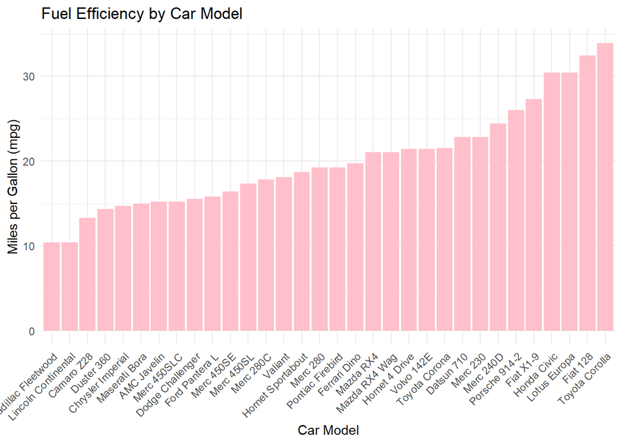

```r
ggplot(mtcars, aes(x = reorder(rownames(mtcars), mpg), y = mpg)) +
    geom_bar(stat = "identity", fill = "pink") +
    labs(title = "Fuel Efficiency by Car Model",
         x = "Car Model",
         y = "Miles per Gallon (mpg)") +
    theme_minimal() +
    theme(axis.text.x = element_text(angle = 45, hjust = 1))
```

2. **Correlation Between Horsepower and Weight**:
- There is a **positive correlation** between horsepower (`hp`) and weight (`wt`).
- Heavier cars tend to have higher horsepower but lower fuel efficiency.

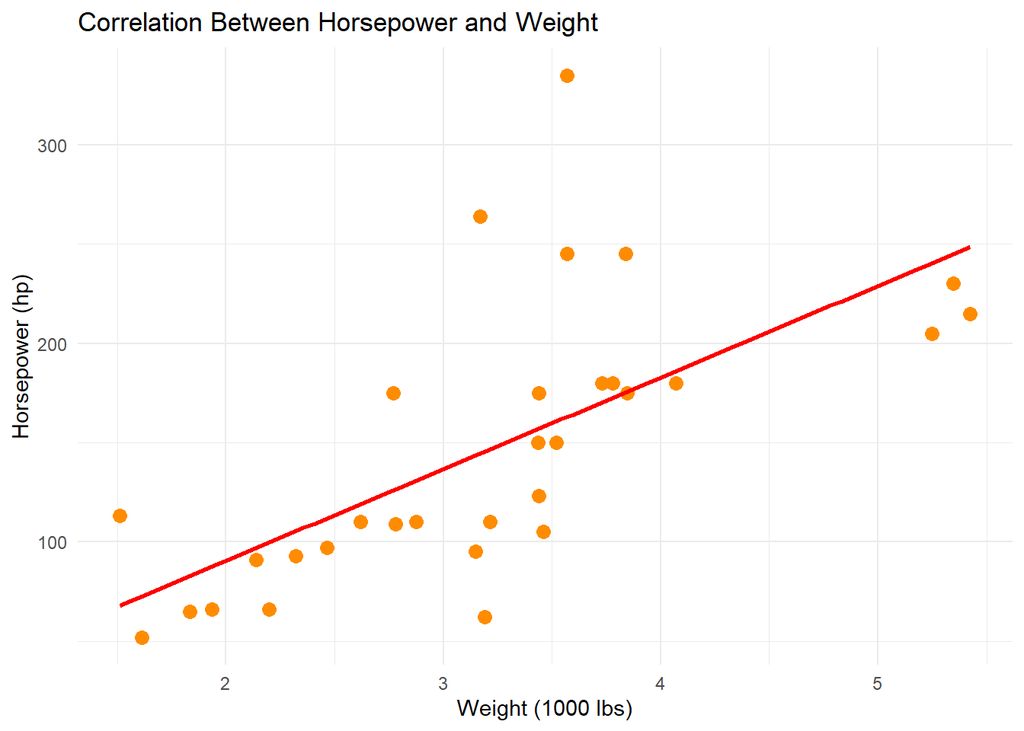

```r
ggplot(mtcars, aes(x = wt, y = hp)) +
    geom_point(color = "darkorange", size = 3) +
    geom_smooth(method = "lm", color = "red", se = FALSE) +
    labs(title = "Correlation Between Horsepower and Weight",
         x = "Weight (1000 lbs)",
         y = "Horsepower (hp)") +
    theme_minimal()
```

Conclusion This analysis provides insights into the relationships between fuel efficiency, horsepower, and weight in the mtcars dataset. The visualizations highlight key trends, such as the positive correlation between horsepower and weight, and the fuel efficiency of different car models.